# Practical Machine Learning Course Project

Pierre McCann

Friday, August 21, 2015

## Introduction

I created my script to allow for reproducibility - both in terms of setting a seed to allow others to reproduce my work, and by passing data to helper functions to ensure that the exact same data cleansing was performed on both the `train` and `test` data sets.

My model is a random forest.

## Configure the environment and load the data

```r
library(caret)
library(randomForest)
library(dplyr)
```

```r
set.seed(125)

#load train data (train.orig)
if(!"pml-training.csv" %in% list.files()){
  download.file("https://d396qusza40orc.cloudfront.net/predmachlearn/pml-training.csv", "pml-training.csv")
}
if(!"train.orig" %in% ls()){
  train.orig <- read.csv("pml-training.csv")
}

#load test data (test.orig)
if(!"pml-testing.csv" %in% list.files()){
  download.file("https://d396qusza40orc.cloudfront.net/predmachlearn/pml-testing.csv", "pml-testing.csv")
}
if(!"test.orig" %in% ls()){
  test.orig <- read.csv("pml-testing.csv")
}
```

## display helper functions

```r
#helper functions
prop.na <- function(x){sum(is.na(x))/length(x)}

clean.data <- function(data){

  ##drop columns with NAs
  x <- data.frame(sapply(data, prop.na))
  vars_to_drop <- rownames(subset(x,x > 0))
  data <- data[, !names(data) %in% vars_to_drop]

  ##drop factor columns
  result <- NULL
  for (i in 1:length(data)){
    if(!is.factor(data[,i])){
      result <- data.frame(cbind(result, as.numeric(data[,i])))
      names(result)[length(result)] <- names(data)[i]
    }
  }

  ##drop the X variable, which appears to be only a serial number
  result <- select(result, -X)
  ##drop the timestamps, because we are making predictions against the movement, not the time the movement took place
  result <- select(result, -raw_timestamp_part_1)
  result <- select(result, -raw_timestamp_part_2)
  ##drop the num_window variable
  result <- select(result, -num_window)

  result
}

pml_write_files = function(x){
  n = length(x)
  for(i in 1:n){
    filename = paste0("problem_id_",i,".txt")
    write.table(x[i],file=filename,quote=FALSE,row.names=FALSE,col.names=FALSE)
  }
}
```

## Selecting features

While examining the data, I noticed that many features were almost entirely `NA`s. I removed these features due to their increase of dimensionality and their lack of information. I also removed all factor columns, largely as an experiment - however, when it worked, I decided to leave them out. Finally, I removed some of the features that appeared to describe information not directly related to the movement - for instance, who was doing the movement or when it was done. I felt that I would be inviting a risk of overfitting if I left those features in place, and so I took them out.

My feature selections ultimately reduced 160 features down to 52. I could have performed additional dimensionality reduction through preprocessing with Principal Components Analysis, but I found my model ended up working well and I could build it in about 30 minutes, using 75% of the original training data (`train.orig`).

## data cleaning and paritioning

```r
#clean the data
train.clean <- clean.data(train.orig)
test.clean <- clean.data(test.orig)

#partition the data
inTrain <- createDataPartition(train.orig$classe, p = 0.75, list = FALSE)

#create new training and testing subsets from the clean training set
train.subset <- train.clean[inTrain,]
test.subset <- train.clean[-inTrain,]
```

## build the model

Random forests do not need additional cross-validation or out-of-sample error estimators, because these metrics are calculated as part of building the model. As a result, I let the random forest build using the default bootstrapping method in the train control. After the model build, I will test my model against the `test.subset` which is about 25% of the original training data `train.orig`.

```r
model <- train(train.orig$classe[inTrain] ~ ., method = "rf", ntree = 250, data = train.subset)
```

With the model built, I can now print some useful information to view the model and estimate my out-of-sample error, which is 0.7%. I can also see from my confusion matrix that my model is about 99.25% accurate.

```r
model$finalModel
```

```
##
## Call:
##  randomForest(x = x, y = y, ntree = 250, mtry = param$mtry)
##                Type of random forest: classification
##                      Number of trees: 250
## No. of variables tried at each split: 27
##
##         OOB estimate of  error rate: 0.7%
## Confusion matrix:
##      A    B    C    D    E class.error
## A 4177    3    3    1    1 0.001911589
## B   19 2824    2    3    0 0.008426966
## C    0   16 2541   10    0 0.010128555
## D    0    2   31 2377    2 0.014510779
## E    0    1    4    5 2696 0.003695492
```

```r
confusionMatrix(predict(model$finalModel, newdata = test.subset), train.orig[-inTrain,"classe"])
```

```
## Confusion Matrix and Statistics
##
##           Reference
## Prediction    A    B    C    D    E
##          A 1394    3    0    0    0
##          B    0  943    2    1    0
##          C    1    3  850   13    1
##          D    0    0    3  790   10
##          E    0    0    0    0  890
##
## Overall Statistics
##
##                Accuracy : 0.9925
##                  95% CI : (0.9896, 0.9947)
##     No Information Rate : 0.2845
##     P-Value [Acc > NIR] : < 2.2e-16
##
##                   Kappa : 0.9905
##  Mcnemar's Test P-Value : NA
##
## Statistics by Class:
##
##                      Class: A Class: B Class: C Class: D Class: E
## Sensitivity            0.9993   0.9937   0.9942   0.9826   0.9878
## Specificity            0.9991   0.9992   0.9956   0.9968   1.0000
## Pos Pred Value         0.9979   0.9968   0.9793   0.9838   1.0000
## Neg Pred Value         0.9997   0.9985   0.9988   0.9966   0.9973
## Prevalence             0.2845   0.1935   0.1743   0.1639   0.1837
## Detection Rate         0.2843   0.1923   0.1733   0.1611   0.1815
## Detection Prevalence   0.2849   0.1929   0.1770   0.1637   0.1815
## Balanced Accuracy      0.9992   0.9965   0.9949   0.9897   0.9939
```

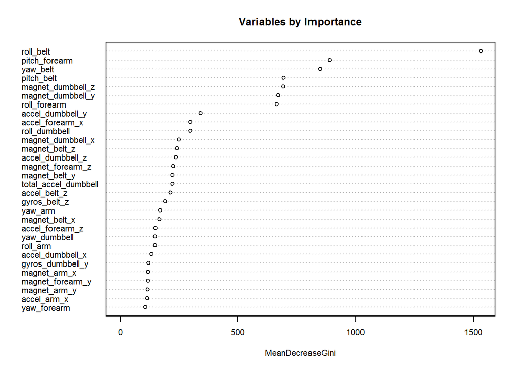

```r
varImpPlot(model$finalModel, cex = 0.7, main = "Variables by Importance")
```

With the model build complete, I can now create my predictions against the given test data which was cleaned above.

```r
predictions <- predict(model$finalModel, newdata = test.clean)
#pml_write_files(predictions) #commented out to prevent the repo from being filled up with files
```